# Udacity Data Analyst Nanodegree

# P5_Explonatory Data Analysis

# Martin Rypar

## UCI Credit Card Dataset

This dataset contains information on default payments, demographic factors, credit data, history of payment, and bill statements of credit card clients in Taiwan from April 2005 to September 2005. The dataset was downloaded from https://www.kaggle.com/uciml/default-of-credit-card-clients-dataset and further informations are avaliable in enclosed P05_Dataset_Description.txt file.

## Preparation and getting some basic intuition of dataset

```
## 'data.frame':    30000 obs. of  28 variables:
##  $ ID       : int  1 2 3 4 5 6 7 8 9 10 ...
##  $ LIMIT_BAL: num  20000 120000 90000 50000 50000 50000 500000 100000 140000 20000 ...
##  $ SEX      : chr  "female" "female" "female" "female" ...
##  $ EDUCATION: chr  "university" "university" "university" "university" ...
##  $ MARRIAGE : chr  "married" "single" "single" "married" ...
##  $ AGE      : int  24 26 34 37 57 37 29 23 28 35 ...
##  $ PAY_0    : chr  "2m" "paid" "revolving" "revolving" ...
##  $ PAY_2    : chr  "2m" "2m" "revolving" "revolving" ...
##  $ PAY_3    : chr  "paid" "revolving" "revolving" "revolving" ...
##  $ PAY_4    : chr  "paid" "revolving" "revolving" "revolving" ...
##  $ PAY_5    : chr  "no consumption" "revolving" "revolving" "revolving" ...
##  $ PAY_6    : chr  "no consumption" "2m" "revolving" "revolving" ...
##  $ BILL_AMT1: num  3913 2682 29239 46990 8617 ...
##  $ BILL_AMT2: num  3102 1725 14027 48233 5670 ...
##  $ BILL_AMT3: num  689 2682 13559 49291 35835 ...
##  $ BILL_AMT4: num  0 3272 14331 28314 20940 ...
##  $ BILL_AMT5: num  0 3455 14948 28959 19146 ...
##  $ BILL_AMT6: num  0 3261 15549 29547 19131 ...
##  $ PAY_AMT1 : num  0 0 1518 2000 2000 ...
##  $ PAY_AMT2 : num  689 1000 1500 2019 36681 ...
##  $ PAY_AMT3 : num  0 1000 1000 1200 10000 657 38000 0 432 0 ...
##  $ PAY_AMT4 : num  0 1000 1000 1100 9000 ...
##  $ PAY_AMT5 : num  0 0 1000 1069 689 ...
##  $ PAY_AMT6 : num  0 2000 5000 1000 679 ...
##  $ default  : chr  "yes" "yes" "no" "no" ...
##  $ default_b: int  1 1 0 0 0 0 0 0 0 0 ...
##  $ BILL_AMT : num  1988 2640 18488 42508 16364 ...
##  $ PAY_AMT  : num  164 667 1458 1587 12593 ...
```

```
##        ID          LIMIT_BAL           SEX             EDUCATION
##  Min.   :    1   Min.   :  10000   Length:30000       Length:30000
##  1st Qu.: 7501   1st Qu.:  50000   Class :character   Class :character
##  Median :15000   Median : 140000   Mode  :character   Mode  :character
##  Mean   :15000   Mean   : 167484
##  3rd Qu.:22500   3rd Qu.: 240000
##  Max.   :30000   Max.   :1000000
##    MARRIAGE              AGE           PAY_0              PAY_2
##  Length:30000       Min.   :21.00   Length:30000       Length:30000
##  Class :character   1st Qu.:28.00   Class :character   Class :character
##  Mode  :character   Median :34.00   Mode  :character   Mode  :character
##                     Mean   :35.49
##                     3rd Qu.:41.00
##                     Max.   :79.00
##     PAY_3              PAY_4              PAY_5
##  Length:30000       Length:30000       Length:30000
##  Class :character   Class :character   Class :character
##  Mode  :character   Mode  :character   Mode  :character
##
##
##
##     PAY_6             BILL_AMT1         BILL_AMT2        BILL_AMT3
##  Length:30000       Min.   :-165580   Min.   :-69777   Min.   :-157264
##  Class :character   1st Qu.:   3559   1st Qu.:  2985   1st Qu.:   2666
##  Mode  :character   Median :  22382   Median : 21200   Median :  20089
##                     Mean   :  51223   Mean   : 49179   Mean   :  47013
##                     3rd Qu.:  67091   3rd Qu.: 64006   3rd Qu.:  60165
##                     Max.   : 964511   Max.   :983931   Max.   :1664089
##    BILL_AMT4         BILL_AMT5        BILL_AMT6          PAY_AMT1
##  Min.   :-170000   Min.   :-81334   Min.   :-339603   Min.   :     0
##  1st Qu.:   2327   1st Qu.:  1763   1st Qu.:   1256   1st Qu.:  1000
##  Median :  19052   Median : 18105   Median :  17071   Median :  2100
##  Mean   :  43263   Mean   : 40311   Mean   :  38872   Mean   :  5664
##  3rd Qu.:  54506   3rd Qu.: 50191   3rd Qu.:  49198   3rd Qu.:  5006
##  Max.   : 891586   Max.   :927171   Max.   : 961664   Max.   :873552
##     PAY_AMT2          PAY_AMT3         PAY_AMT4         PAY_AMT5
##  Min.   :      0   Min.   :     0   Min.   :     0   Min.   :     0.0
##  1st Qu.:    833   1st Qu.:   390   1st Qu.:   296   1st Qu.:   252.5
##  Median :   2009   Median :  1800   Median :  1500   Median :  1500.0
##  Mean   :   5921   Mean   :  5226   Mean   :  4826   Mean   :  4799.4
##  3rd Qu.:   5000   3rd Qu.:  4505   3rd Qu.:  4013   3rd Qu.:  4031.5
##  Max.   :1684259   Max.   :896040   Max.   :621000   Max.   :426529.0
##     PAY_AMT6          default            default_b         BILL_AMT
##  Min.   :     0.0   Length:30000       Min.   :0.0000   Min.   :-29465
##  1st Qu.:   117.8   Class :character   1st Qu.:0.0000   1st Qu.:  4889
##  Median :  1500.0   Mode  :character   Median :0.0000   Median : 21980
##  Mean   :  5215.5                      Mean   :0.2212   Mean   : 47170
##  3rd Qu.:  4000.0                      3rd Qu.:0.0000   3rd Qu.: 60405
##  Max.   :528666.0                      Max.   :1.0000   Max.   :873217
##     PAY_AMT
##  Min.   :     0
##  1st Qu.:  1228
##  Median :  2488
##  Mean   :  5418
##  3rd Qu.:  5696
##  Max.   :805850
```

## Univariate Plots Section

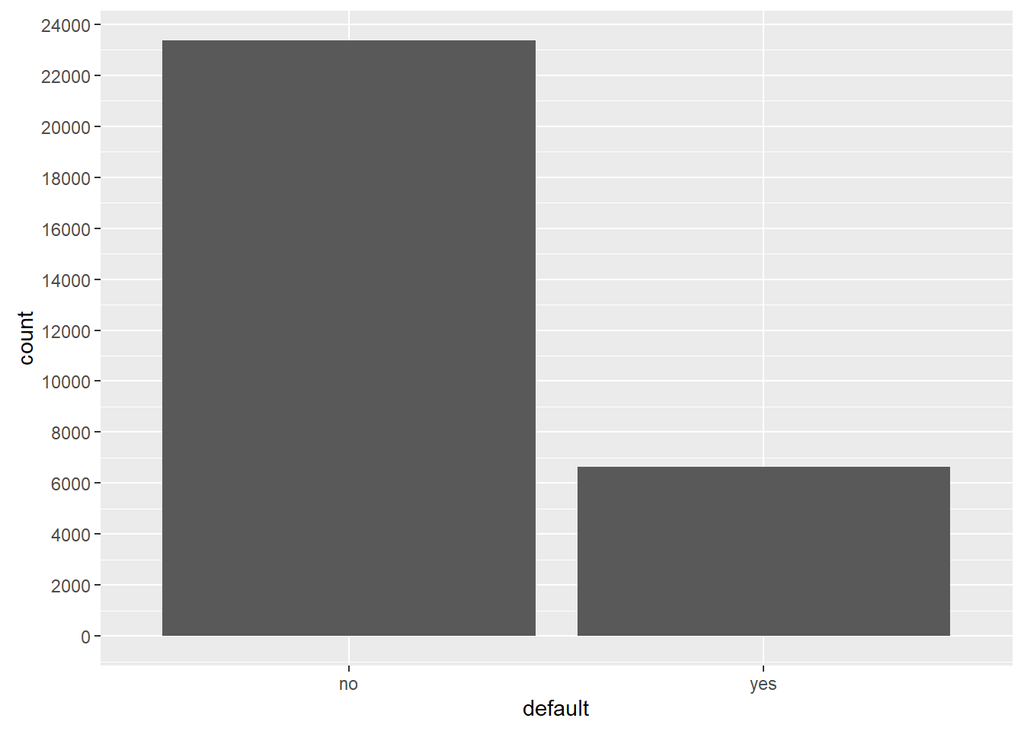

As I am mainly interested in default variable, lets look at number of default vs non default customers. It is clear that default variable is not equally distributed, as most of the customers will not default.

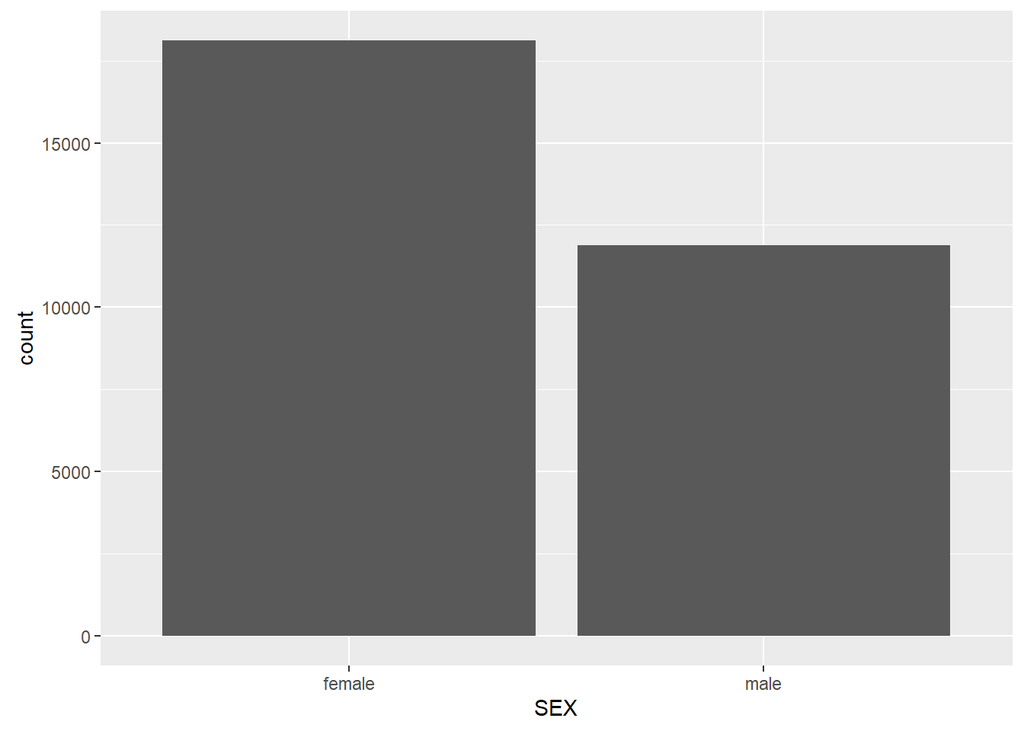

Now lets look at the categorical variables. One would expect similar number of males and females within dataset, but here is a quite gap between those two on behalf of females.

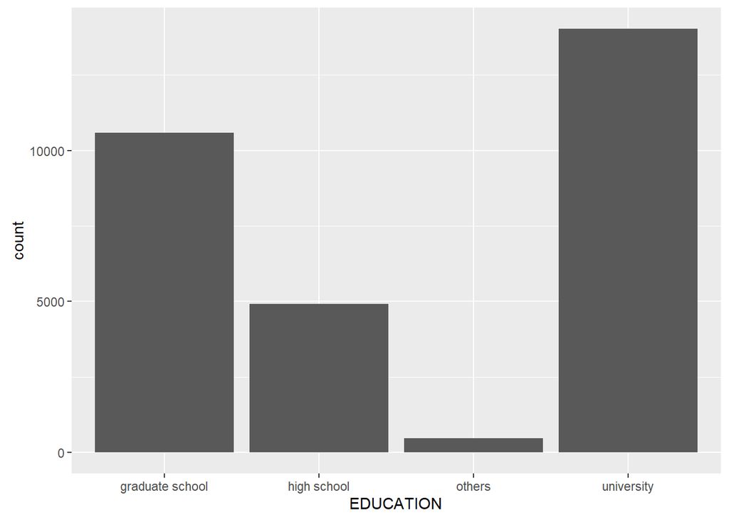

Education features is neither equally distributed as majority of people attended university (university, graduate school) and others variable which has arguable information value but I decided to keep those observations in.

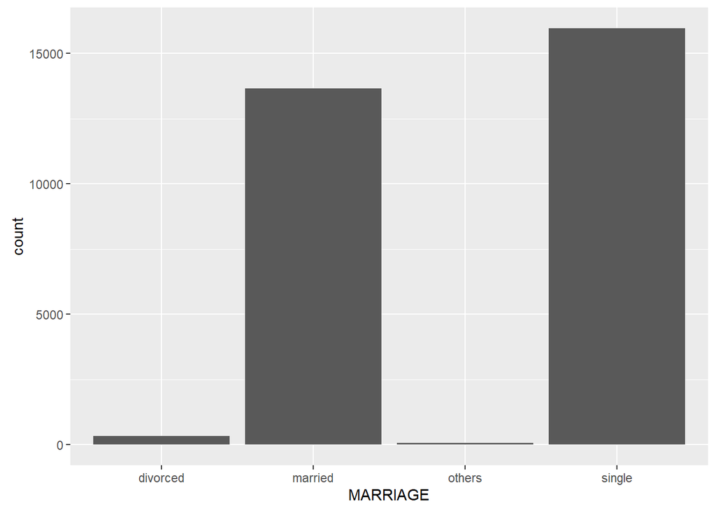

The majority of dataset is consisted of similar number of single and married customers, only a fraction of dataset are divorced and again others which meaning is not completely clear again.

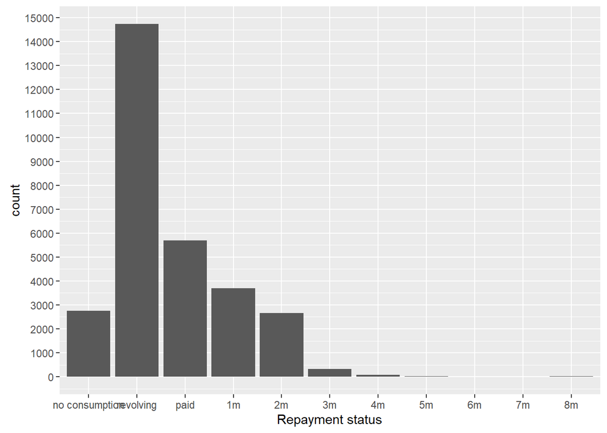

Possibly the most important feature - repayment status. Plot showing repayment status of customer in last recorded month (September), (-2: No consumption; -1: Paid in full; 0:The use of revolving credit; 1 = payment delay for one month; 2 = payment delay for two months; . . .; 8 = payment delay for eight months; 9 = payment delay for nine months and above) Distribution almost like a skewed, if we would not take into account no consumption. Plot also suggests that credit card users pay their debts most often by using revolving credit.

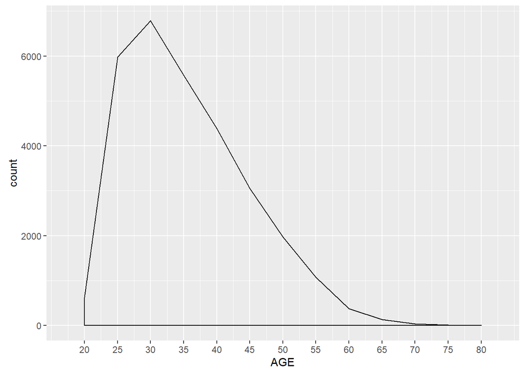

And now quantitative features. Clearly skewed distribution of age features shows that majority of people using credit cards are people ~ 25-40 years old.

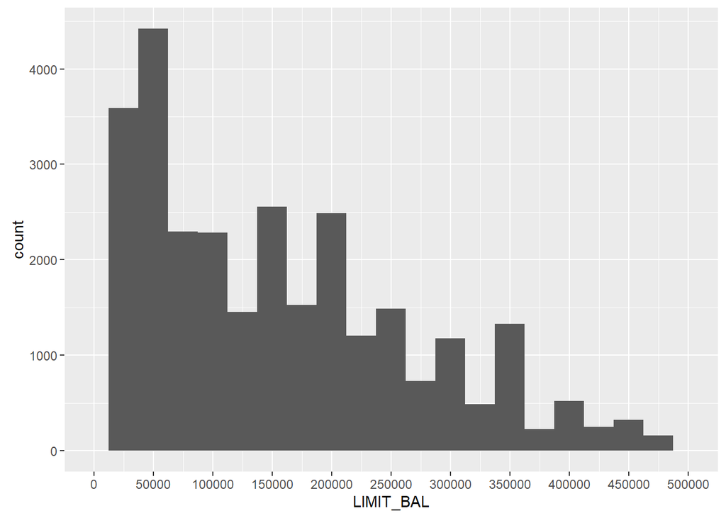

LIMIT_BAL feature shows histogram of initial deposits where the distribution might remind skewed distribution. This variable may be important as people with bigger initial deposit might be less prone to default.

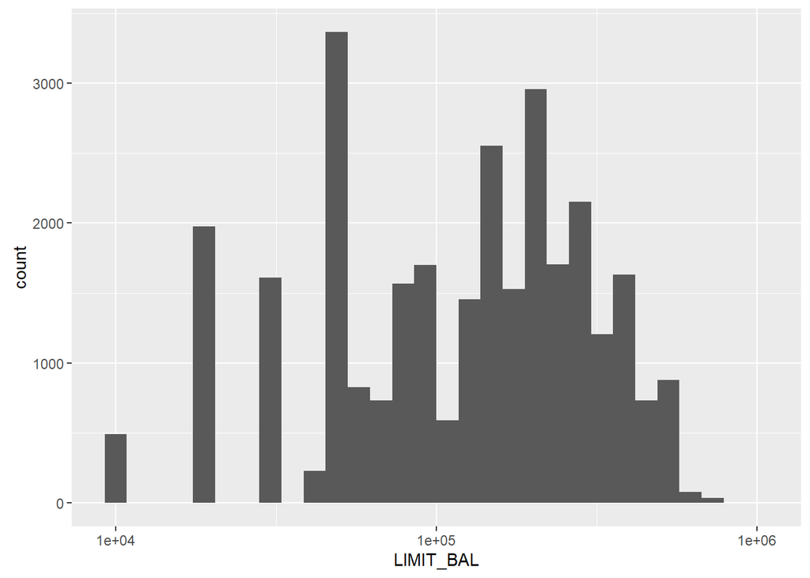

Same plot as before only with after log transformation of x axis. Not particularly helpful.

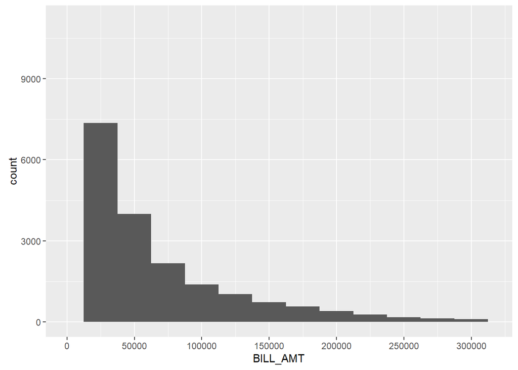

Plot depicts histogram of different averages of amounts of bill statement, where it shows again skewed distribution. I am interested in this feature as it could cluster customers by their amount of bill statement and thus might contain signal whether is some cluster more prone to default.

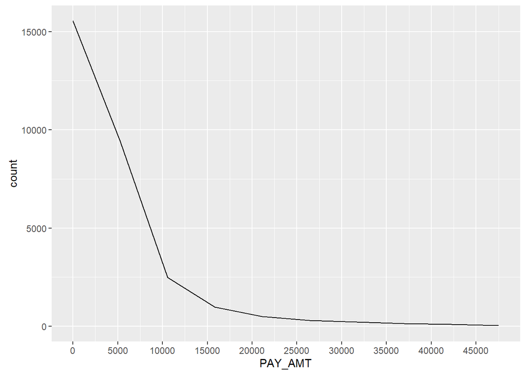

Histogram with average volume of previous payments again with strongly skewed distribution, in conformity with plot 5, which showed that most of the people use revolving credit to repay and thus do not pay directly which is depicted here.

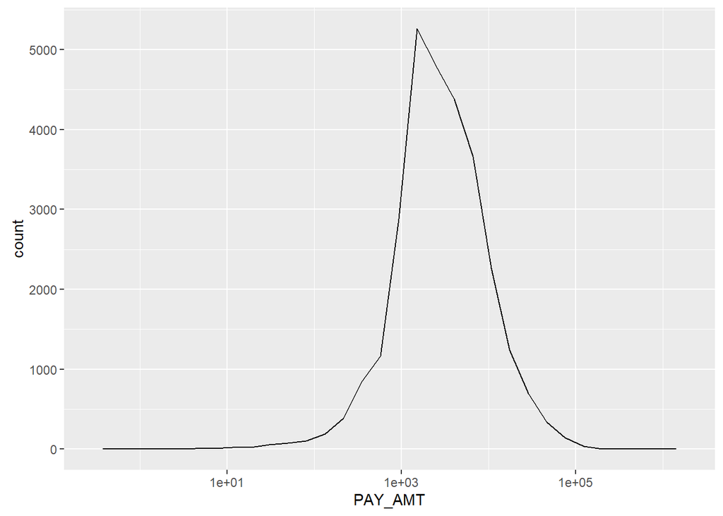

After log transformation of x axis of the previous plot, we can see plot more similar to normal distribution.

## Univariate Analysis

The dataset consists of 30 000 observations and 25 variables (age, sex, education, marriage, amount of given credit, repayment status 1-6 months back, amount of bill statement 1-6 months back, amount of previous payments 1-6 months back, default) where I am mainly interested in how is default variable (customer will not be able to pay his/her debts in next month) affected by other variables. Closer description can be found in enclosed P05_Description_Dataset.txt file.

First I recoded some of the categorical variables from their previous numerical coding (dummy variables) to more explicit and easy to read naming in order to have more clear plot descriptions.

Next I created two new variables: From amount of bill statements for last 6 months (BILL_AMT) were calculated weighted averages for each customer with biggest weight on the most recent record and smallest weight on the oldest record. Similarly were calculated weighted average PAY_AMT of payments for last 6 months.

#### Categorical Variables

- ~22% is general proportion of defaulted customers within dataset
- More than a half of the dataset consists of females
- The most usual customer has university degree
- More than a half of customers are single
- The majority of people use revolving credit to pay debts

#### Quantitative Variables

- Age as skewed distribution (long-tail) with majority of customers within 25-40 years old (older people do not use the credit cards and they prefer cash in most of the cases), median age 34 and proportion of defaulted customers remains between 0.2 and 0.3 with an exception of customers older than 70 years, where is huge gap and approx. only a half of people around 75 y.o. paid their debts.
- LIMIT_BAL (amount of given credit) variable seems to have roughly skewed distribution
- Average amount of bill statement (BILL_AMT) has the skewed distribution
- The most common average of previous payments (PAY_AMT) is ~ 2000 NT dollars and again is of skewed distribution

In general the goal of ploting all the plots were to get some intuition and basic understnading of how the dataset looks like and find out what are distributions of particular features.

## Bivariate Plots Section

As I have mentioned before, I am mainly interested wheter customer will default or not in the following month. So now I am going to look at the differences within customers divided per certain characteristics and wheter they default or not, in other words I am going to look at the proportions of defaulted vs non defaulted based on their attributes such as age, sex, education etc.

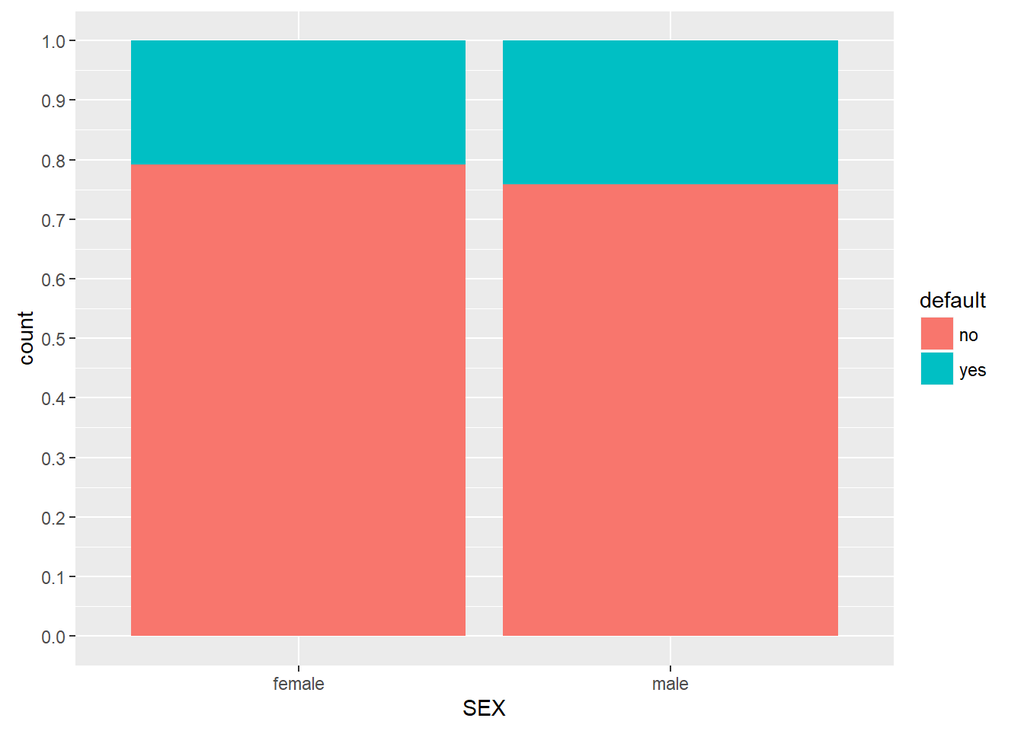

One can notice that within females is default rate slightly lower ~0.21 than within males ~0.24, which might indicate that females are more responsible when repaying debts.

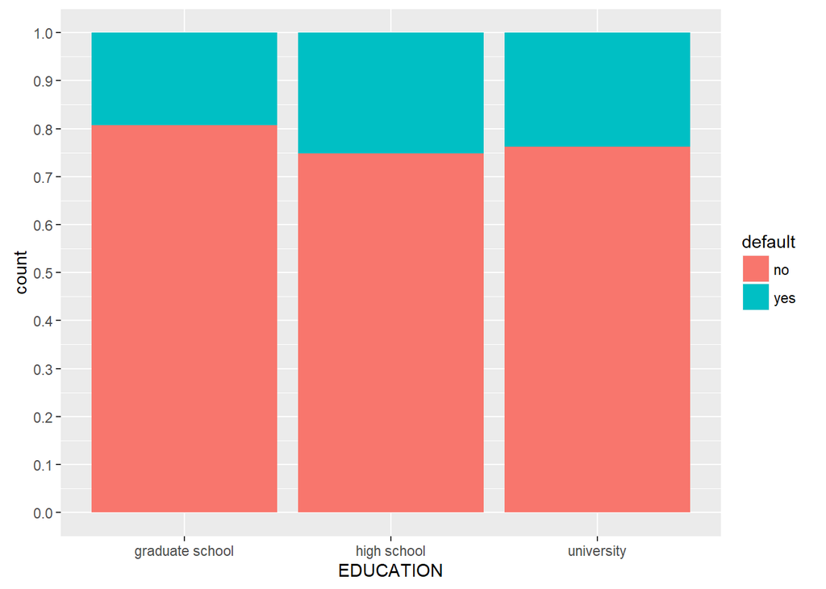

Also education could be one of the important features helping to estimate wheter customer will default or not. Hypothesis is that customers with a better education tend to default in lower proportion than customers with a worse education. Some differencies might be noticed when looking at the plot, where customers finished graduate school (the highest academical degree within dataset) have the lowest proportion of defaults ~0.19 and people finished only high school (the lowest academical degree within dataset) have the highest proportion of defaults ~0.25. University absolvents somewhere between ~0.23 and others were excluded from plot due to lack of records.

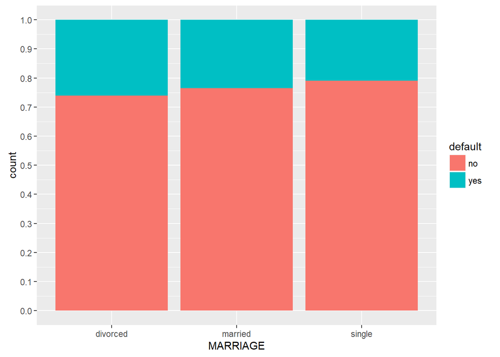

Marriage variable could also help to estimate potential default of customers, thats why I ploted this graph. Single customers with the lowest proportion of defaults ~0.21, married slightly worse ~0.23 and divorced ~0.26. Others were again excluded - same reason as before.

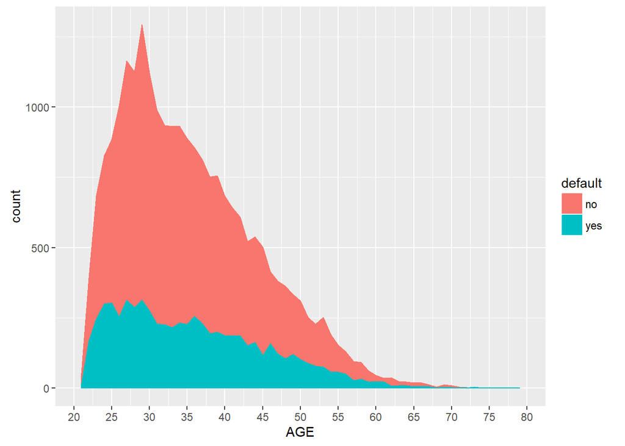

Next I would like to see if age distribution is somehow different based on default and non default customers. Plot shows that the curves are similar, but the default customers curve seems to decrease much slower, it has much smaller slope opposite to non default customers. That might indicate that customer between 35 - 60 are more likely to default.

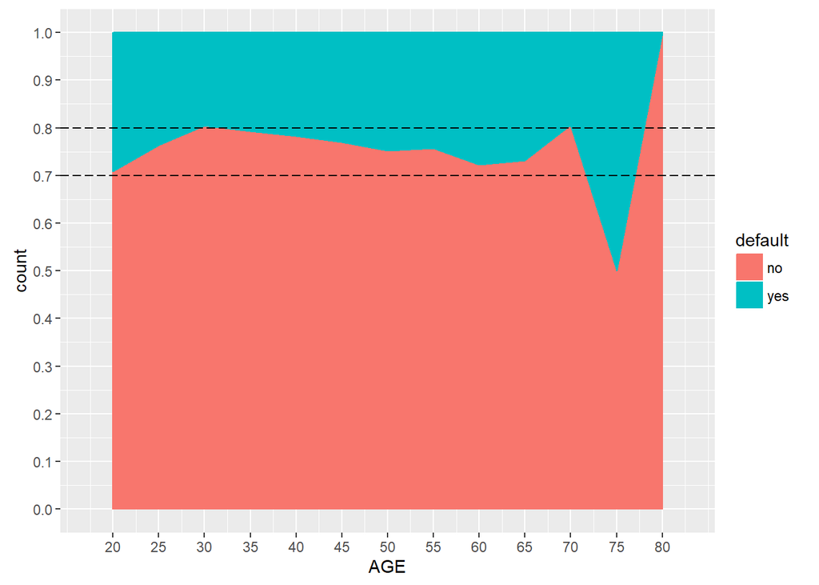

To examine my conjecture, lets look at more closely. There is no clear evidence After a while playing with the binwidth, there is some signs of increasing proportion of defaults with increasing age within 35 - 60 range, but it is not clear evidence that older people defaults more often than younger as the end of the curve is very volatile which could be caused by lack of observations.

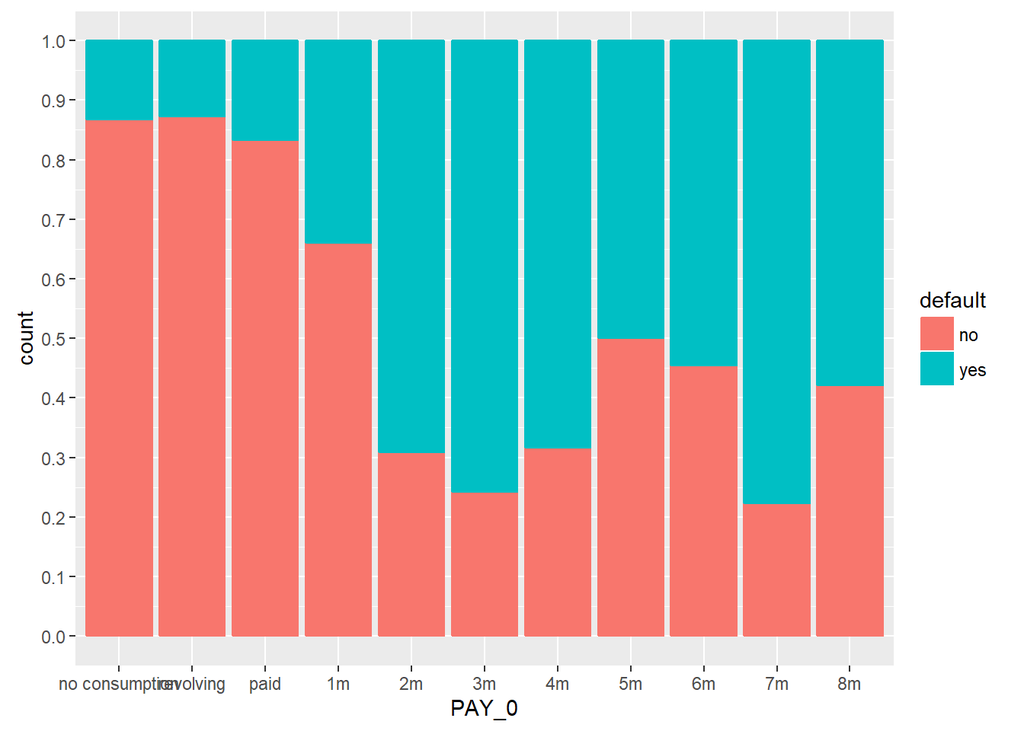

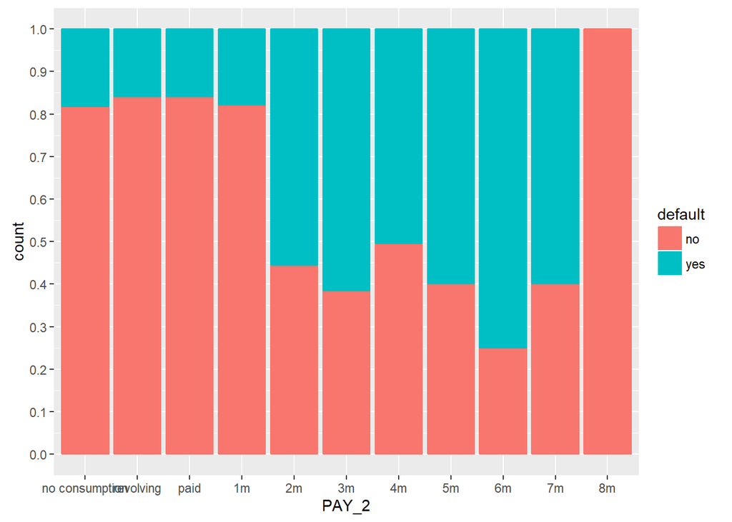

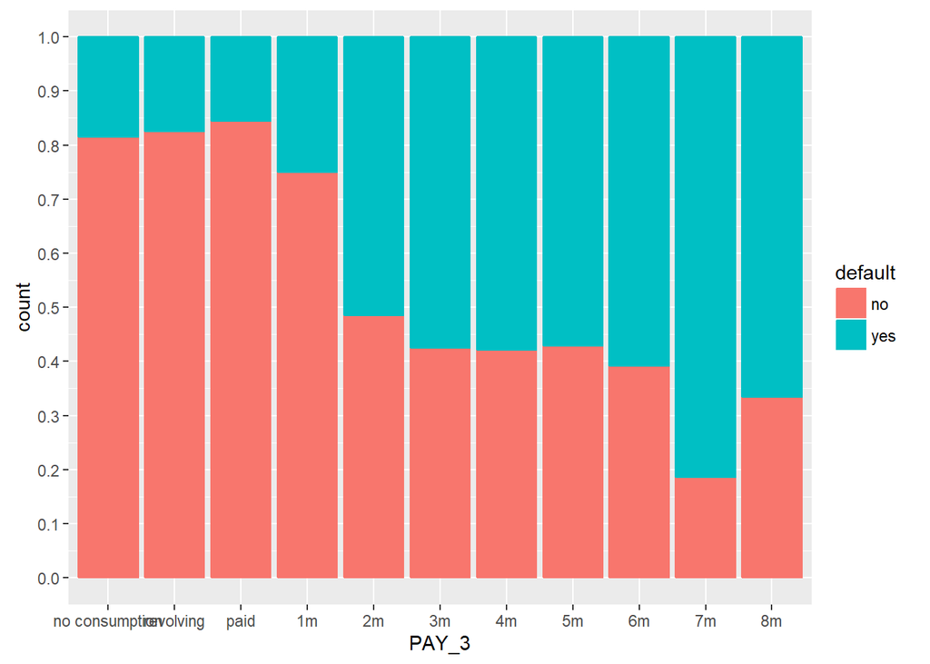

To examine payment status for last 3 month and proportion of defaults I have ploted the 3 above graphs, which showing that no within no consumption, revolving, paid and 1m delay is proportion of defaults clearly minimal ~0.2. But with delay 2 months and more the proportion of defaults dramatically increased ~0.6. The most significant gap is between 1m delay and 2m delay, which is sign that if customer is not able to repay the debt until 1m delay then the chance of repayment rapidly decrease.

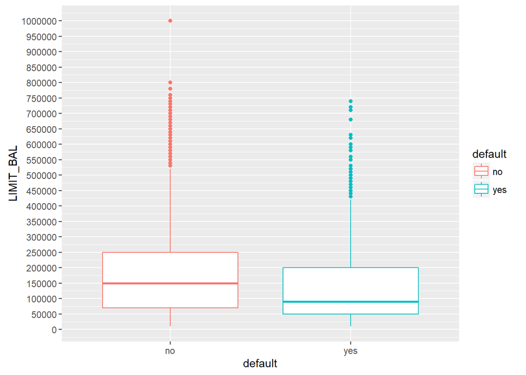

Do customers with different initial deposits diverse based on default information? Yes, it seems so. Customers who defaulted have lower median of initial deposits opposite to them who did not default.

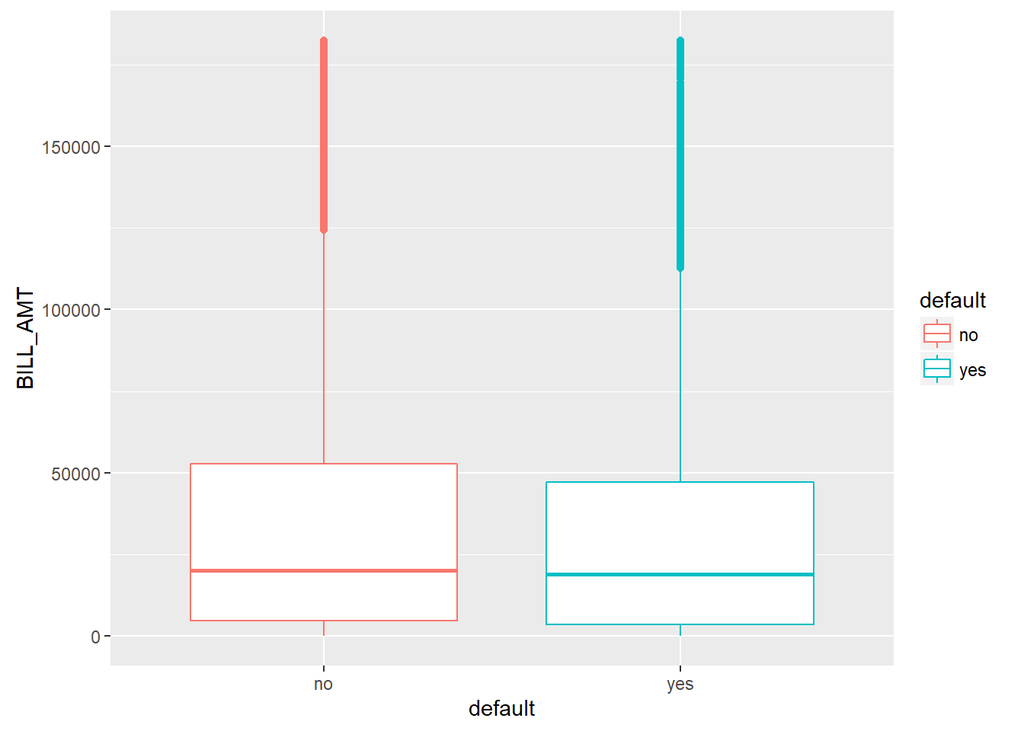

But same which apply for initial deposit, does not apply for average amount of bill statement. There median relatively same for both groups - default and non default. Top 5% values were cut off to eliminate outliers.

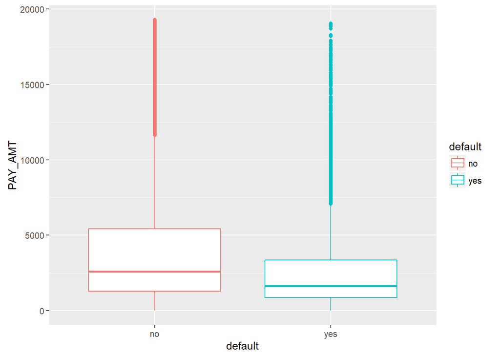

And as could be expected the average amount of previous payments have higher median within non defaulted customers, which is quite obvious that customers who pay their debts could not be in default. Top 5% values were cut off to eliminate outliers.

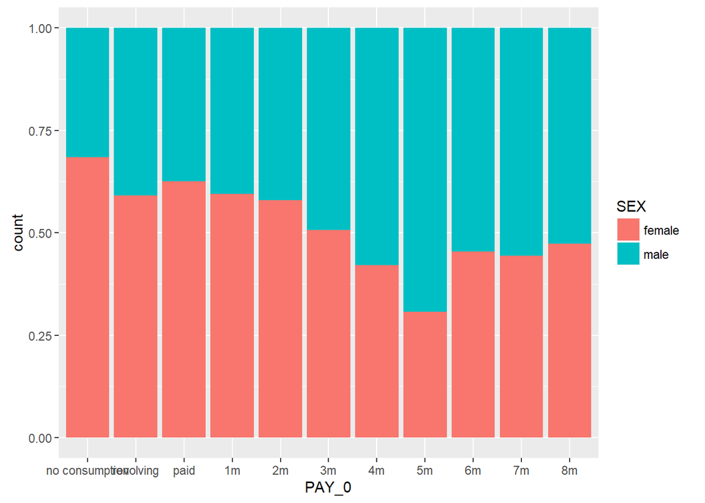

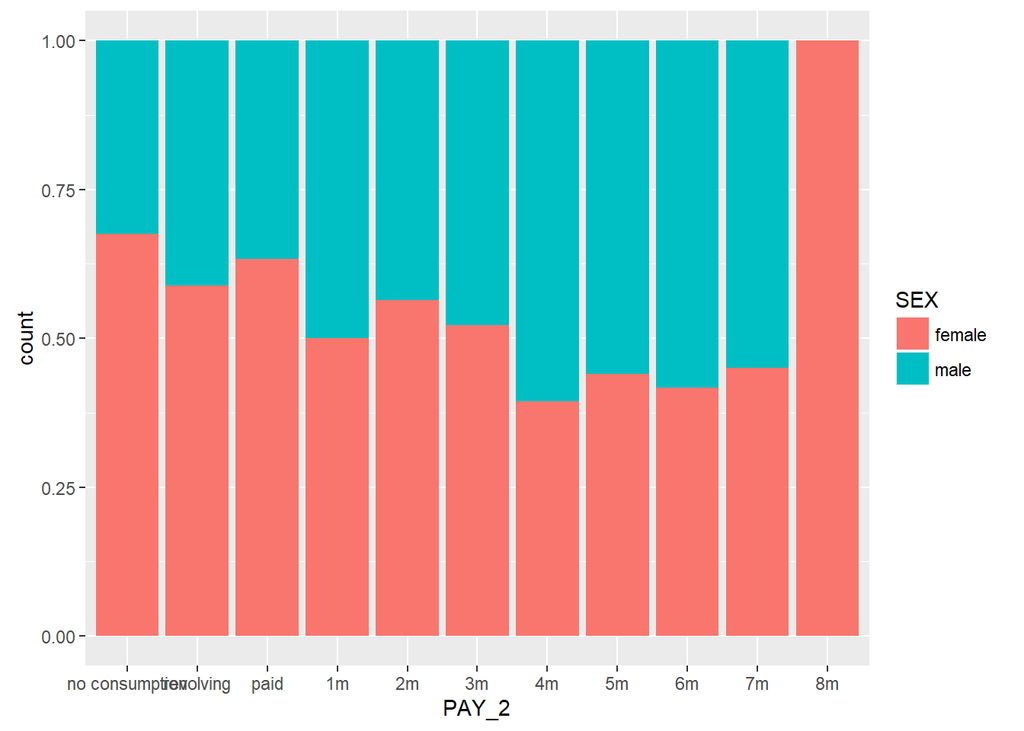

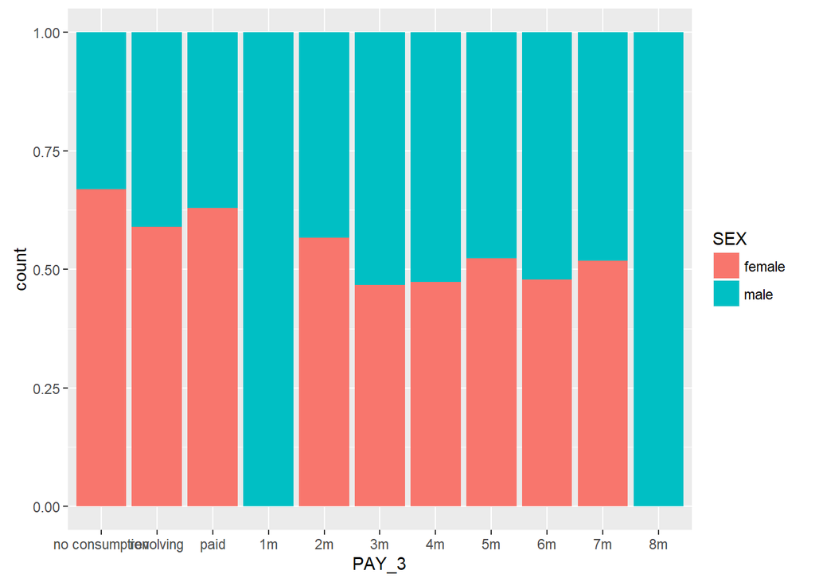

To analyze not only default feature, but also other features I ploted those 3 graphs above, where is noticeable difference in males and females repayment morale. Females seem to be more responsible in repayments, the proportion of females within no consumpion, revolving and paid is clearly bigger than males proportion. Also females have shorter delays of repayments. Also it worths notice that there is a quite difference in count of females and males in the dataset on behalf of females.

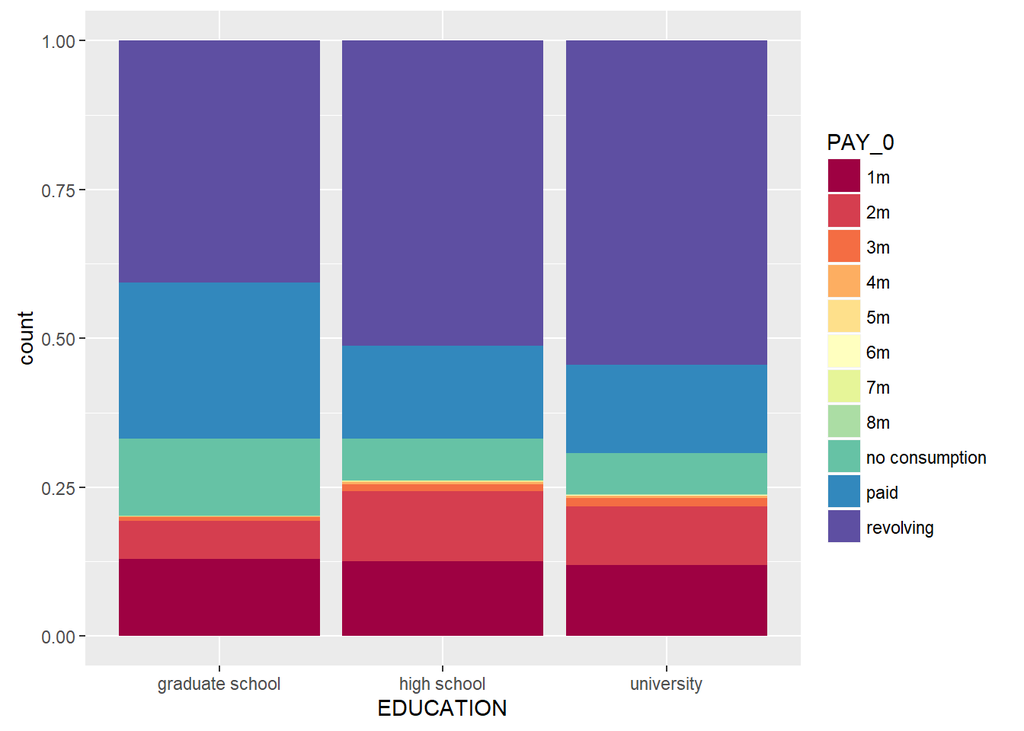

To get some intuition about repayment morale per education I generated this plot above. Where clear dominance of revolving repayment is striking, only within graduate school absolvents it looks like they are more conscientious and instead of revolving they repaid the debt also significant part is no consumption within this group and generaly it is obvious that best repayment morale have group - gradute school. High school and university graduates shown worse opposite to graduate school but with only minimal differencies between those two groups.

## Bivariate Analysis

Within majority of features is proportion between default and non default customers very small (sex, education, marriage) but within some of the features we can find strong contrast (PAY_0, PAY_2, PAY_3) as those features could be much stronger in discrimination of default and non default customers.

I would expect that females are better in repaying their debts, but I was slightly surprised by about how much are they better and about how much better is their repayment morale at least within this dataset. The rest of the features behave in conformity with my expectations.

What it worths to say is that this kind of data are related to culture and part of the world from where it were collected as in western countries there is probably different handling with money opposite to eastern countries etc. Also this data represents mainly younger and middle-aged generation ~20-55, where dataset primary consists of people that age.

#### Key findings:

- The proportion of defaulted customers per sex is slightly bigger within males
- The proportion of defaulted customers per education seems to be highest within customers who completed only high school (but universtity graduates close enough)
- The biggest proportion of defaults showed divorced customers
- The most significant change in proportion of defaulted and non defaulted customers repeatedly occured between 1 month delay in payment and 2 months delay in payment - which draggs my attention
- LIMIT_BAL (amount of given credit) variable has higher median within non defaulted customers
- Average amount of bill statement (BILL_AMT) do not shows any significant differencies within people who default and those who do not
- As expected average amount of previous payments (PAY_AMT) has higher median within people who do not default but with a higher variance
- Females seem to be better debtors as they pay on time more often then males and the delay seems to be shorter as well for women

## Multivariate Plots Section

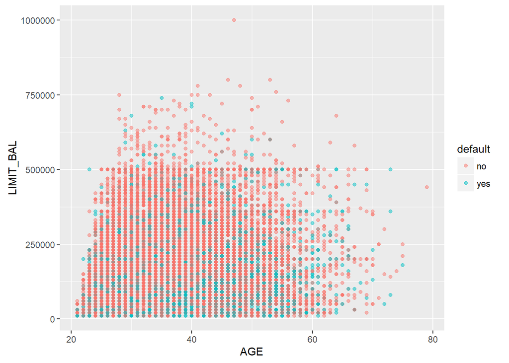

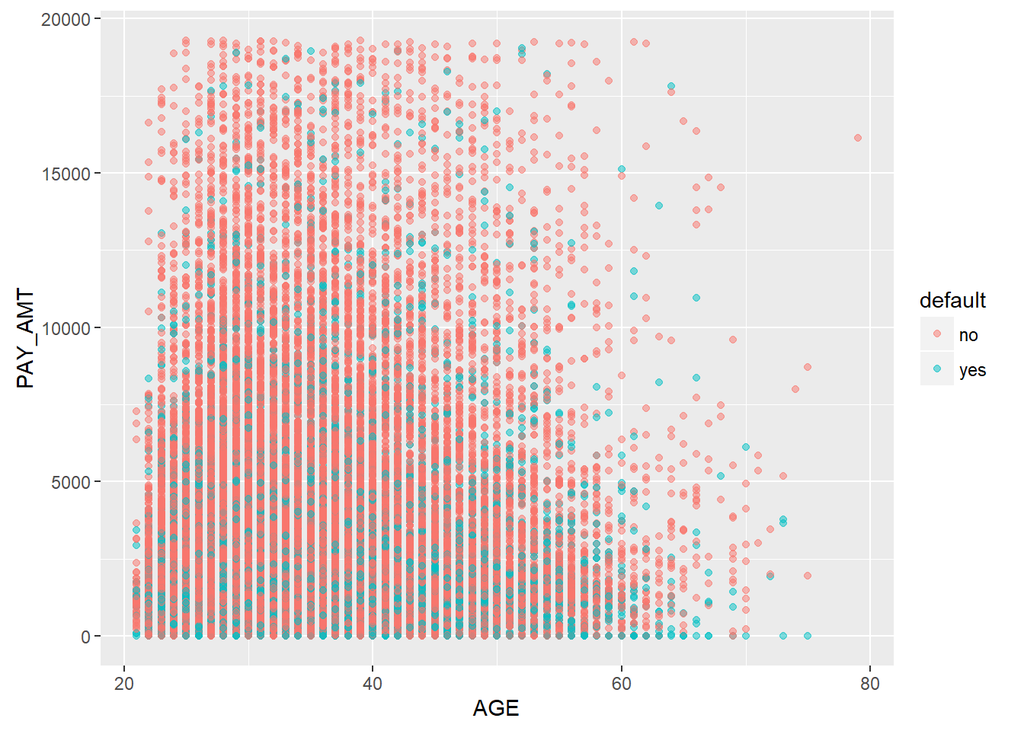

My idea was that maybe older people tends to have much bigger initial deposit as they are probably more conservative so I took a shot at it. Similarly I did for amount of paid money. Neither one of the plots does show any clear pattern, even though on the age~initial deposit plot seems that default customers concentrate very close to x-axis with minimal initial deposit. Which might be interpreted as people with lower initial deposit are more likely to default.

```
##
## Call:
## glm(formula = default_b ~ ., family = binomial(link = "logit"),
##     data = train_data)
##
## Deviance Residuals:
##     Min       1Q   Median       3Q      Max
## -1.9679  -0.6057  -0.5302  -0.3013   3.4307
##
## Coefficients:
##                        Estimate Std. Error z value Pr(>|z|)
## (Intercept)          -4.098e-01  1.860e-01  -2.203   0.0276 *
## LIMIT_BAL            -2.240e-06  1.836e-07 -12.203  < 2e-16 ***
## SEXmale               1.486e-01  3.578e-02   4.153 3.28e-05 ***
## EDUCATIONhigh school -3.588e-02  5.524e-02  -0.650   0.5160
## EDUCATIONothers      -1.309e+00  2.352e-01  -5.565 2.62e-08 ***
## EDUCATIONuniversity   8.152e-03  4.073e-02   0.200   0.8414
## MARRIAGEmarried       6.925e-02  1.585e-01   0.437   0.6622
## MARRIAGEothers       -1.418e+00  6.513e-01  -2.177   0.0295 *
## MARRIAGEsingle       -1.037e-01  1.603e-01  -0.647   0.5178
## AGE                   1.527e-03  2.157e-03   0.708   0.4789
## PAY_02m               1.311e+00  6.241e-02  21.001  < 2e-16 ***
## PAY_03m               1.582e+00  1.519e-01  10.414  < 2e-16 ***
## PAY_04m               1.069e+00  2.657e-01   4.022 5.78e-05 ***
## PAY_05m               5.125e-01  4.958e-01   1.034   0.3014
## PAY_06m               6.238e-01  6.745e-01   0.925   0.3550
## PAY_07m               1.958e+00  1.084e+00   1.807   0.0708 .
## PAY_08m               4.421e-01  4.781e-01   0.925   0.3551
## PAY_0no consumption  -8.512e-01  7.857e-02 -10.833  < 2e-16 ***
## PAY_0paid            -6.260e-01  5.726e-02 -10.933  < 2e-16 ***
## PAY_0revolving       -1.285e+00  5.004e-02 -25.681  < 2e-16 ***
## BILL_AMT              2.849e-06  3.600e-07   7.914 2.49e-15 ***
## PAY_AMT              -3.572e-05  3.795e-06  -9.414  < 2e-16 ***
## ---
## Signif. codes:  0 '***' 0.001 '**' 0.01 '*' 0.05 '.' 0.1 ' ' 1
##
## (Dispersion parameter for binomial family taken to be 1)
##
##     Null deviance: 25517  on 23999  degrees of freedom
## Residual deviance: 21423  on 23978  degrees of freedom
## AIC: 21467
##
## Number of Fisher Scoring iterations: 5
```

Before creating a model I split the data into train set and test set and afterwards used glm() function to create logistic regression model with summary above.

```
## Analysis of Deviance Table
##
## Model: binomial, link: logit
##
## Response: default_b
##
## Terms added sequentially (first to last)
##
##
##           Df Deviance Resid. Df Resid. Dev  Pr(>Chi)
## NULL                      23999      25517
## LIMIT_BAL  1    579.6     23998      24938 < 2.2e-16 ***
## SEX        1     25.4     23997      24912 4.551e-07 ***
## EDUCATION  3     67.4     23994      24845 1.519e-14 ***
## MARRIAGE   3     62.1     23991      24783 2.125e-13 ***
## AGE        1      0.6     23990      24782    0.4202
## PAY_0     10   3216.3     23980      21566 < 2.2e-16 ***
## BILL_AMT   1     20.8     23979      21545 5.196e-06 ***
## PAY_AMT    1    121.8     23978      21423 < 2.2e-16 ***
## ---
## Signif. codes:  0 '***' 0.001 '**' 0.01 '*' 0.05 '.' 0.1 ' ' 1
```

Then to find out how particular features help to reduce residual deviance in other words, how well they are helpful with improvement of the model, ANOVA summary is showed above.

```
## [1] "Accuracy 0.8295"
```

After fitting model to test set to find out how well the model predicts wheter customer will default or not, accuracy is calculated.

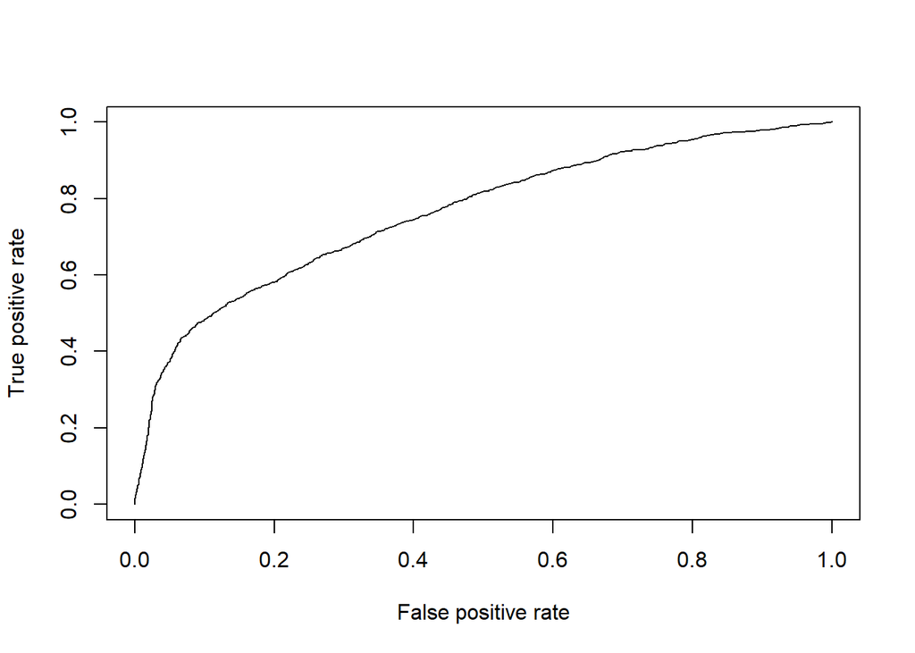

```
## [1] "AUC Accuracy:  0.7637"
```

The ploted curve, called ROC, generated by plotting the true positive rate (TPR) against the false positive rate (FPR) at various threshold settings and AUC Accuracy are different measures of accuracy of the model, widely used for classification tasks.

## Multivariate Analysis

To sum up the first two plots: Observation that customers with higher initial deposit default in less cases than customers with lower deposit was strenghten. No clear evidence of that previous payments are dependent on age of customers.

As the decision if the customer will default in next month is classification task with two possible outputs I tried to model this task with a logistic regression model (binary logistic regression). First I very simply divide dataset into two groups: training data - on which I will train the model and estimate its parameters and test data - on which I will test the accuracy of its predictions.

The majority of features are statistical significant at least at the 0.05 level. But some of the features are not, such as PAY_5m, PAY_6m, PAY_8m EDUCATIONhigh school, EDUCATIONuniversity, MARRIAGEmarried, MARRIAGEsingle, AGE.

According to absolute values of estimates of categorical features it seems that PAY_0 has strong impact on the output of model. The SEX feature increases value of function by 0.1486 for males which means that within males is slightly bigger chance of default, if the SEX is female then value of function do not change (this relationship is partially reflected in intercept). The SEX features is in conformity with my previous findings, on the other hand within the EDUCATION features it does not seem so. My findigs are that high school customers are more likely to default opposite to university customers whereas in the model it is contrarily. That might points out on that the model is not perfect.

Model confirm my findigns from previous parts such as: the higher initial deposit (LIMIT_BAL) the lower probability of default or males are more likely to default than females. The difference between the null deviance and the residual deviance shows how the model is doing against the null model (a model with only the intercept). The wider this gap, the better. Noticeable decrease of Residual Deviance caused adding PAY_0 (repayment status) feature into model and also LIMIT_BAL (initial deposit) feature.

Accuracy 0.8295 represents how precise is model when predicting default status on a new set of data. AUC (area under the curve) is another measure of accuracy, typical for classification tasks ranging from 0 to 1 (closer to 1 is better model). The ROC is a curve generated by plotting the true positive rate (TPR) against the false positive rate (FPR) at various threshold settings while the AUC is the area under the ROC curve. My model shows AUC 0.76 which is better than random guessing (AUC 0.5) but in general 0.76 is not very precise and at this kind of task is demanded much better precision thus the model could be significantly improved.

## Final Plots and Summary

### Plot One

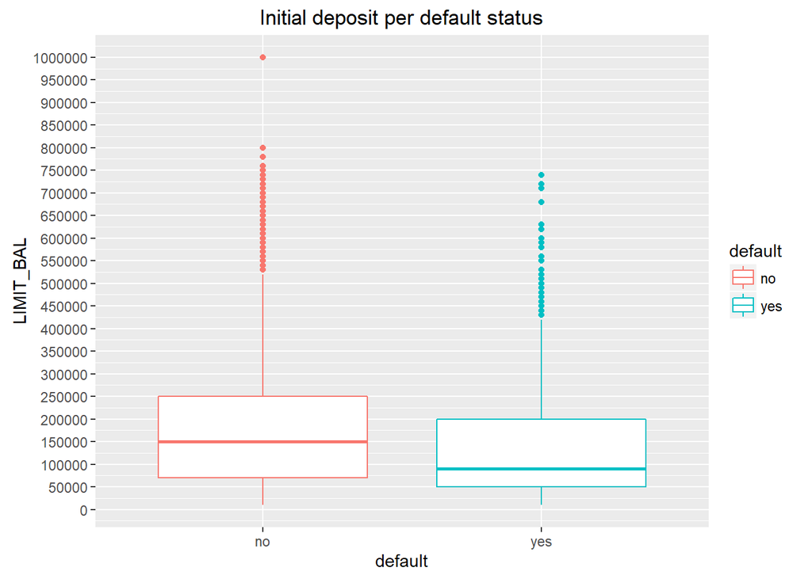

### Description One

The first plot shows how initial deposit(LIMIT_BAL) vary between default statuses, even though it is simple plot it shows valuable information that non defaulted customers have higher median of the deposit compared to customers who defaulted. And this information could be very quickly used by bank or other financial institution exposed to credit risk to for example analyze minimal level of initial deposit.

### Plot Two

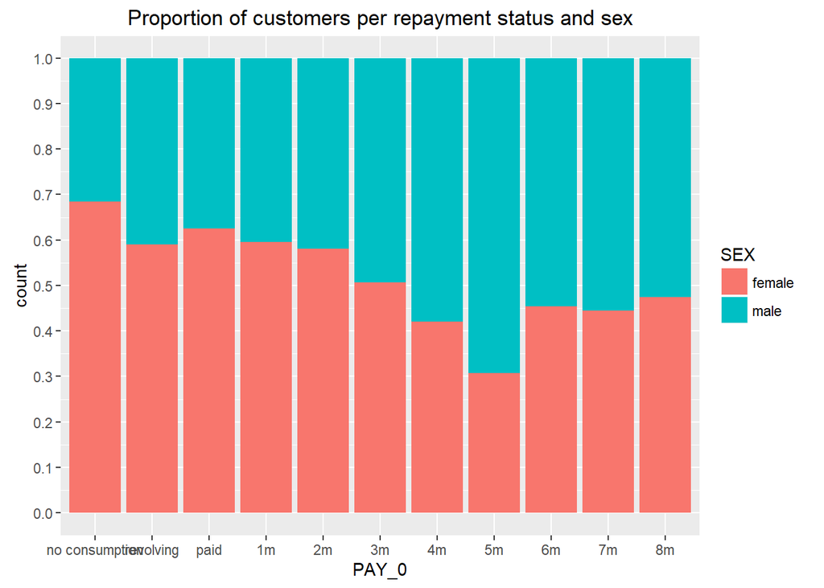

### Description Two

I like this one because it nicely develops the finding that females are better in repaying their debts within this dataset. Where the proportion in groups like no consumption, revolving and paid are clearly bigger within females. Also trend seems to prompt that males have longer delays in repayment. This was observed also in different months (PAY_2, PAY_3, …).

### Plot Three

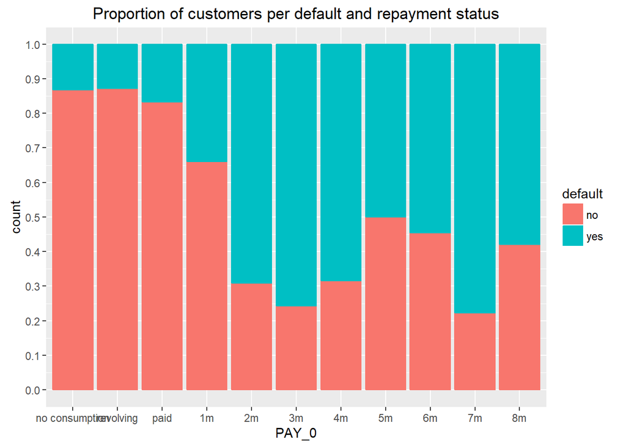

### Description Three

The third plot is very similar to second one, but brings very different insights and also offers one interesting thing. The plot shows proportion of defaulted customers per repayment status in last month, where is clear that customers with longer delay will default with much bigger probability. The interesting thing is that not only in the last month but even in previous months there is a big gap in proportion of defaults between one month dealay and two months delay. It is sign that if customer is not able to repay his/her debt until one month delay, the chances of repayment are dramatically dragged down.

## Reflection

A lot of insights are very intuitive and could be expected, nevertheless thats the one of the reasons of doing such analysis - to confirm or disprove  
the ideas, intuitions and expectations about the data. After few projects in Python a was quite comfortable with the language and thus the change of the environment was a bit painfull for me even though I like R and I like how easy is to do the nice plots in it. And also during analysis I struggled a little bit with continuity as I often leave the analysis and then return to it after few days and I felt like I lost the connection and I had to remind myself all the previous parts. On the other hand it has also positive side that it could bring some new points of view and ideas.

In future work I would like to develop better model by tuning the one I used - as my approach was quite simple (e.g. division of dataset could be done better as accuracy is dependent on the manual split to training and test set, prepare better features) or develop more advanced and more sophisticated classification models (neural networks, naive bayes or decision trees).

## Sources

http://www.cookbook-r.com/Graphs/Colors_(ggplot2)/ https://www.kaggle.com/moscolitos/exploratory-data-analysis/code https://s3.amazonaws.com/content.udacity-data.com/ courses/ud651/diamondsExample_2016-05.html  
https://stackoverflow.com/questions/31561238/ lapply-function-loops-on-list-of-lists-r  
http://www.cookbook-r.com/Graphs/Colors_(ggplot2)/ https://www.r-bloggers.com/how-to-perform-a-logistic-regression-in-r/ http://r-statistics.co/Logistic-Regression-With-R.html